# HEC-RAS Pipes, Conduits, and Pump Stations HDF Data Analysis Notebook

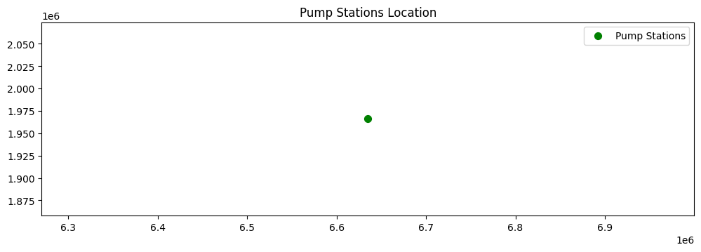

```python
# Visualize pump stations on a map
fig, ax = plt.subplots(figsize=(12, 8))
pump_stations_gdf.plot(ax=ax, color='green', markersize=50, label='Pump Stations')
ax.set_title('Pump Stations Location')
ax.legend()
plt.show()
```

```python
# Example 3: Get pipe network timeseries
valid_variables = [
    "Cell Courant", "Cell Water Surface", "Face Flow", "Face Velocity",
    "Face Water Surface", "Pipes/Pipe Flow DS", "Pipes/Pipe Flow US",
    "Pipes/Vel DS", "Pipes/Vel US", "Nodes/Depth", "Nodes/Drop Inlet Flow",
    "Nodes/Water Surface"
]

print("Valid variables for pipe network timeseries:")
for var in valid_variables:
    print(f"- {var}")

# Extract pipe network timeseries for each valid pipe-related variable
pipe_variables = [var for var in valid_variables if var.startswith("Pipes/") or var.startswith("Nodes/")]

for variable in pipe_variables:
    try:
        pipe_timeseries = HdfPipe.get_pipe_network_timeseries(plan_hdf_path, variable=variable)
        print(f"\nPipe Network Timeseries ({variable}):")
        print(pipe_timeseries.head())  # Print first few rows to avoid overwhelming output
    except Exception as e:
        print(f"Error extracting {variable}: {str(e)}")
```

[output not shown]

```
Valid variables for pipe network timeseries:
- Cell Courant
- Cell Water Surface
- Face Flow
- Face Velocity
- Face Water Surface
- Pipes/Pipe Flow DS
- Pipes/Pipe Flow US
- Pipes/Vel DS
- Pipes/Vel US
- Nodes/Depth
- Nodes/Drop Inlet Flow
- Nodes/Water Surface

Pipe Network Timeseries (Pipes/Pipe Flow DS):
<xarray.DataArray 'Pipes/Pipe Flow DS' (time: 5, location: 5)> Size: 100B
array([[ 0.0000000e+00,  0.0000000e+00,  0.0000000e+00,  0.0000000e+00,
         0.0000000e+00],
       [-0.0000000e+00, -0.0000000e+00, -0.0000000e+00, -0.0000000e+00,
        -0.0000000e+00],
       [-0.0000000e+00, -0.0000000e+00, -0.0000000e+00, -0.0000000e+00,
        -0.0000000e+00],
       [-0.0000000e+00, -6.6351867e-03, -0.0000000e+00, -0.0000000e+00,
        -0.0000000e+00],
       [-0.0000000e+00, -1.5214826e-01, -0.0000000e+00, -0.0000000e+00,
         1.2617193e-07]], dtype=float32)
Coordinates:
  * time      (time) datetime64[ns] 40B 2000-01-10T12:00:00 ... 2000-01-10T12...
  * location  (location) int32 20B 0 1 2 3 4
Attributes:
    units:     ft^3/s
    variable:  Pipes/Pipe Flow DS

Pipe Network Timeseries (Pipes/Pipe Flow US):
<xarray.DataArray 'Pipes/Pipe Flow US' (time: 5, location: 5)> Size: 100B
array([[ 0.0000000e+00,  0.0000000e+00,  0.0000000e+00,  0.0000000e+00,
         0.0000000e+00],
       [-0.0000000e+00, -0.0000000e+00, -0.0000000e+00, -0.0000000e+00,
        -0.0000000e+00],
       [-0.0000000e+00, -0.0000000e+00, -0.0000000e+00, -0.0000000e+00,
```

[output cut: 74 more lines]

```

Pipe Network Timeseries (Nodes/Water Surface):
<xarray.DataArray 'Nodes/Water Surface' (time: 5, location: 5)> Size: 100B
array([[26.98    , 25.79    , 28.87    , 27.36    , 24.6     ],
       [26.93429 , 25.742727, 28.838373, 27.345407, 24.6     ],
       [26.93429 , 25.742727, 28.838373, 27.35843 , 24.6     ],
       [26.93429 , 25.742727, 28.838373, 27.482279, 24.6     ],
       [26.93429 , 25.742727, 28.909948, 27.620935, 24.6     ]],
      dtype=float32)
Coordinates:
  * time      (time) datetime64[ns] 40B 2000-01-10T12:00:00 ... 2000-01-10T12...
  * location  (location) int32 20B 0 1 2 3 4
Attributes:
    units:     ft
    variable:  Nodes/Water Surface
```

### Pipe Network Timeseries Data Description

The `get_pipe_network_timeseries` function returns an xarray DataArray for each variable. Here's a general description of the data structure:

1. **Pipes/Pipe Flow DS and Pipes/Pipe Flow US**:
   - Dimensions: time, location (pipe IDs)
   - Units: ft^3/s (cubic feet per second)
   - Description: Represents the flow rate at the downstream (DS) and upstream (US) ends of pipes over time.
2. **Pipes/Vel DS and Pipes/Vel US**:
   - Dimensions: time, location (pipe IDs)
   - Units: ft/s (feet per second)
   - Description: Shows the velocity at the downstream (DS) and upstream (US) ends of pipes over time.
3. **Nodes/Depth**:
   - Dimensions: time, location (node IDs)
   - Units: ft (feet)
   - Description: Indicates the depth of water at each node over time.
4. **Nodes/Drop Inlet Flow**:
   - Dimensions: time, location (node IDs)
   - Units: cfs (cubic feet per second)
   - Description: Represents the flow rate through drop inlets at each node over time.
5. **Nodes/Water Surface**:
   - Dimensions: time, location (node IDs)
   - Units: ft (feet)
   - Description: Shows the water surface elevation at each node over time.

General notes:

- The 'time' dimension represents the simulation timesteps.
- The 'location' dimension represents either pipe IDs or node IDs, depending on the variable.
- The number of timesteps and locations may vary depending on the specific dataset and simulation setup.
- Negative values in flow variables may indicate reverse flow direction.

```
2024-11-06 16:39:50,365 - ras_commander.HdfPipe - INFO - Calling get_pipe_network_timeseries
2024-11-06 16:39:50,367 - ras_commander.HdfPipe - INFO - Using HDF file: c:\GH\ras-commander\examples\example_projects\Davis\DavisStormSystem.p02.hdf
2024-11-06 16:39:50,379 - ras_commander.HdfPipe - INFO - Finished get_pipe_network_timeseries
```

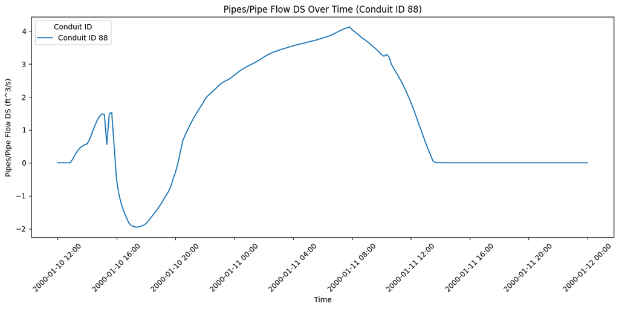

```
2024-11-06 16:39:50,725 - ras_commander.HdfPipe - INFO - Calling get_pipe_network_timeseries
2024-11-06 16:39:50,727 - ras_commander.HdfPipe - INFO - Using HDF file: c:\GH\ras-commander\examples\example_projects\Davis\DavisStormSystem.p02.hdf
2024-11-06 16:39:50,736 - ras_commander.HdfPipe - INFO - Finished get_pipe_network_timeseries
```

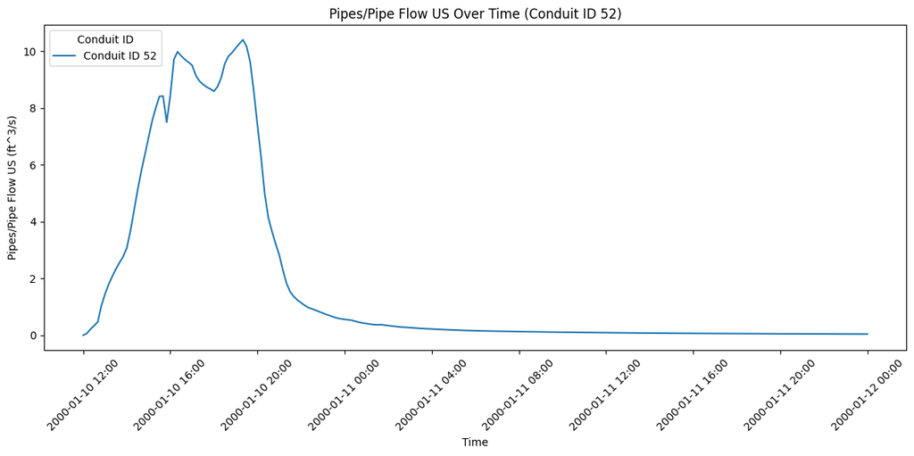

```
2024-11-06 16:39:51,092 - ras_commander.HdfPipe - INFO - Calling get_pipe_network_timeseries
2024-11-06 16:39:51,094 - ras_commander.HdfPipe - INFO - Using HDF file: c:\GH\ras-commander\examples\example_projects\Davis\DavisStormSystem.p02.hdf
2024-11-06 16:39:51,105 - ras_commander.HdfPipe - INFO - Finished get_pipe_network_timeseries
```

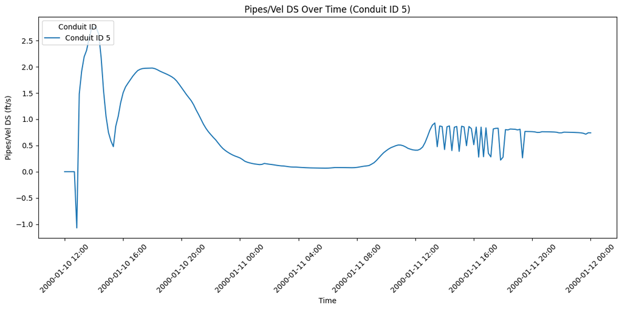

```
2024-11-06 16:39:51,505 - ras_commander.HdfPipe - INFO - Calling get_pipe_network_timeseries
2024-11-06 16:39:51,507 - ras_commander.HdfPipe - INFO - Using HDF file: c:\GH\ras-commander\examples\example_projects\Davis\DavisStormSystem.p02.hdf
2024-11-06 16:39:51,520 - ras_commander.HdfPipe - INFO - Finished get_pipe_network_timeseries
```

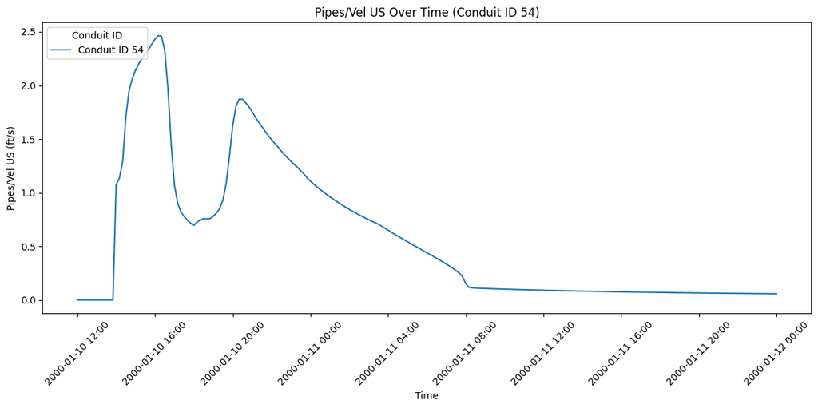

```
2024-11-06 16:39:51,879 - ras_commander.HdfPipe - INFO - Calling get_pipe_network_timeseries
2024-11-06 16:39:51,880 - ras_commander.HdfPipe - INFO - Using HDF file: c:\GH\ras-commander\examples\example_projects\Davis\DavisStormSystem.p02.hdf
2024-11-06 16:39:51,891 - ras_commander.HdfPipe - INFO - Finished get_pipe_network_timeseries
```

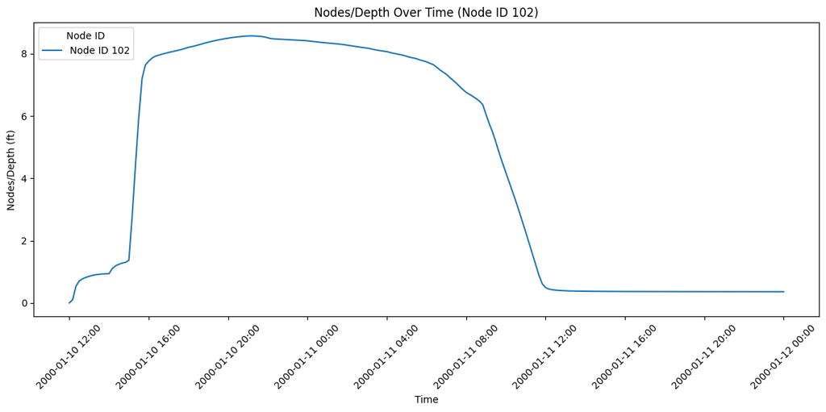

```
2024-11-06 16:39:52,236 - ras_commander.HdfPipe - INFO - Calling get_pipe_network_timeseries
2024-11-06 16:39:52,238 - ras_commander.HdfPipe - INFO - Using HDF file: c:\GH\ras-commander\examples\example_projects\Davis\DavisStormSystem.p02.hdf
2024-11-06 16:39:52,254 - ras_commander.HdfPipe - INFO - Finished get_pipe_network_timeseries
```

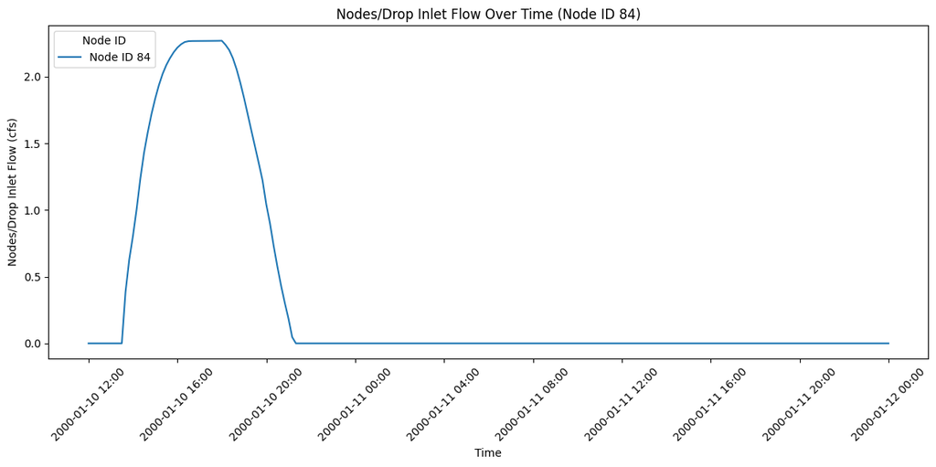

```
2024-11-06 16:39:52,624 - ras_commander.HdfPipe - INFO - Calling get_pipe_network_timeseries
2024-11-06 16:39:52,626 - ras_commander.HdfPipe - INFO - Using HDF file: c:\GH\ras-commander\examples\example_projects\Davis\DavisStormSystem.p02.hdf
2024-11-06 16:39:52,640 - ras_commander.HdfPipe - INFO - Finished get_pipe_network_timeseries
```

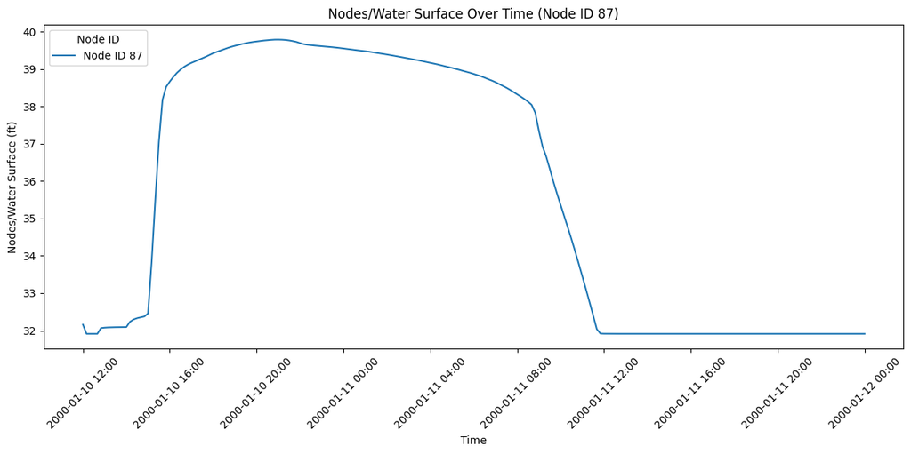

```python
import matplotlib.pyplot as plt
from matplotlib.dates import DateFormatter
import numpy as np
import random

# Define the variables we want to plot
variables = [
    "Pipes/Pipe Flow DS", "Pipes/Pipe Flow US", "Pipes/Vel DS", "Pipes/Vel US",
    "Nodes/Depth", "Nodes/Drop Inlet Flow", "Nodes/Water Surface"
]

# Create a separate plot for each variable
for variable in variables:
    try:
        # Get the data for the current variable
        data = HdfPipe.get_pipe_network_timeseries(plan_hdf_path, variable=variable)

        # Create a new figure
        fig, ax = plt.subplots(figsize=(12, 6))

        # Pick one random location
        random_location = random.choice(data.location.values)

        # Determine if it's a pipe or node variable
        if variable.startswith("Pipes/"):
            location_type = "Conduit ID"
        else:
            location_type = "Node ID"

        # Plot the data for the randomly selected location
        ax.plot(data.time, data.sel(location=random_location), label=f'{location_type} {random_location}')

        # Set the title and labels
        ax.set_title(f'{variable} Over Time ({location_type} {random_location})')
        ax.set_xlabel('Time')  # Corrected from ax.xlabel to ax.set_xlabel
        ax.set_ylabel(f'{variable} ({data.attrs["units"]})')  # Corrected from ax.ylabel to ax.set_ylabel

        # Format the x-axis to show dates nicely
        ax.xaxis.set_major_formatter(DateFormatter('%Y-%m-%d %H:%M'))
        plt.xticks(rotation=45)

        # Add a legend
        ax.legend(title=location_type, loc='upper left')

        # Adjust the layout
        plt.tight_layout()

        # Show the plot
        plt.show()

    except Exception as e:
        print(f"Error plotting {variable}: {str(e)}")
```

```python
# Example 8: Get pump station timeseries
pump_station_name = pump_stations_gdf.iloc[0]['Name']  # Get the first pump station name
# Use the results_pump_station_timeseries method
pump_timeseries = HdfPump.get_pump_station_timeseries(plan_hdf_path, pump_station=pump_station_name)
print(f"\nPump Station Timeseries ({pump_station_name}):")
print(pump_timeseries)
```

```
2024-11-06 16:39:53,352 - ras_commander.HdfPump - INFO - Calling get_pump_station_timeseries
2024-11-06 16:39:53,354 - ras_commander.HdfPump - INFO - Using HDF file: c:\GH\ras-commander\examples\example_projects\Davis\DavisStormSystem.p02.hdf
2024-11-06 16:39:53,370 - ras_commander.HdfPump - INFO - Finished get_pump_station_timeseries
```

```
Pump Station Timeseries (Pump Station #1):
<xarray.DataArray 'Pump Station #1' (time: 217, variable: 5)> Size: 4kB
array([[ 0.      , 24.6     , 38.888123,  0.      ,  0.      ],
       [ 0.      , 24.6     , 38.888123,  0.      ,  0.      ],
       [ 0.      , 24.6     , 38.888123,  0.      ,  0.      ],
       ...,
       [ 0.      , 26.59624 , 40.429493,  0.      ,  0.      ],
       [ 0.      , 25.379211, 40.796555,  0.      ,  0.      ],
       [ 0.      , 25.607447, 40.661793,  0.      ,  0.      ]],
      dtype=float32)
Coordinates:
  * time      (time) datetime64[ns] 2kB 2000-01-10T12:00:00 ... 2000-01-12
  * variable  (variable) <U12 240B 'Flow' 'Stage HW' ... 'Pumps on'
Attributes:
    units:         [[b'Flow' b'cfs']\n [b'Stage HW' b'ft']\n [b'Stage TW' b'f...
    pump_station:  Pump Station #1
```

```python
# Use get_hdf5_dataset_info function to get Pipe Conduits data:
HdfBase.get_dataset_info(plan_hdf_path, "/Geometry/Pump Stations/")
```

```
2024-11-06 16:39:53,393 - ras_commander.HdfBase - INFO - Using HDF file: c:\GH\ras-commander\examples\example_projects\Davis\DavisStormSystem.p02.hdf
```

```
Exploring group: /Geometry/Pump Stations/


    Dataset: /Geometry/Pump Stations//Attributes
        Shape: (1,)
        Dtype: [('Name', 'S16'), ('Inlet River', 'S16'), ('Inlet Reach', 'S16'), ('Inlet RS', 'S8'), ('Inlet RS Distance', '<f4'), ('Inlet SA/2D', 'S16'), ('Inlet Pipe Node', 'S32'), ('Outlet River', 'S16'), ('Outlet Reach', 'S16'), ('Outlet RS', 'S8'), ('Outlet RS Distance', '<f4'), ('Outlet SA/2D'…

    Dataset: /Geometry/Pump Stations//Points
        Shape: (1, 2)
        Dtype: float64
    Attributes for /Geometry/Pump Stations//Points:
        Column: b'X,Y'
        Row: b'Points'

    Group: /Geometry/Pump Stations//Pump Groups
        Dataset: /Geometry/Pump Stations//Pump Groups/Attributes
            Shape: (1,)
            Dtype: [('Pump Station ID', '<i4'), ('Name', 'S16'), ('Bias On', 'u1'), ('Start Up Time', '<f4'), ('Shut Down Time', '<f4'), ('Width', '<f4'), ('Pumps', '<i4')]
        Dataset: /Geometry/Pump Stations//Pump Groups/Efficiency Curves Info
            Shape: (1, 2)
            Dtype: int32
    Attributes for /Geometry/Pump Stations//Pump Groups/Efficiency Curves Info:
        Column: [b'Starting Index' b'Count']
        Row: b'Feature'
        Dataset: /Geometry/Pump Stations//Pump Groups/Efficiency Curves Values
            Shape: (6, 2)
            Dtype: float32
    Attributes for /Geometry/Pump Stations//Pump Groups/Efficiency Curves Values:
        Column: [b'Head' b'Flow']
        Row: b'Points'
        Group: /Geometry/Pump Stations//Pump Groups/Pumps
            Dataset: /Geometry/Pump Stations//Pump Groups/Pumps/Attributes
                Shape: (1,)
                Dtype: [('Pump Group ID', '<i4'), ('Name', 'S16'), ('WS On', '<f4'), ('WS Off', '<f4'), ('Default Centerline', 'u1')]
            Dataset: /Geometry/Pump Stations//Pump Groups/Pumps/Centerline Info
                Shape: (1, 4)
                Dtype: int32
    Attributes for /Geometry/Pump Stations//Pump Groups/Pumps/Centerline Info:
        Column: [b'Point Starting Index' b'Point Count' b'Part Starting Index'
 b'Part Count']
        Feature Type: b'Polyline'
        Row: b'Feature'
            Dataset: /Geometry/Pump Stations//Pump Groups/Pumps/Centerline Parts
                Shape: (1, 2)
                Dtype: int32
    Attributes for /Geometry/Pump Stations//Pump Groups/Pumps/Centerline Parts:
        Column: [b'Point Starting Index' b'Point Count']
        Row: b'Part'
            Dataset: /Geometry/Pump Stations//Pump Groups/Pumps/Centerline Points
                Shape: (2, 2)
                Dtype: float64
    Attributes for /Geometry/Pump Stations//Pump Groups/Pumps/Centerline Points:
        Column: [b'X' b'Y']
        Row: b'Points'
            Dataset: /Geometry/Pump Stations//Pump Groups/Pumps/Outlet Cells
                Shape: (1,)
                Dtype: [('Pump Station ID', '<i4'), ('Pump Group ID', '<i4'), ('Pump ID', '<i4'), ('Cell Index', '<i4'), ('Station Start', '<f4'), ('Station End', '<f4')]
```

```
2024-11-06 16:39:53,441 - ras_commander.HdfPump - INFO - Calling get_pump_station_timeseries
2024-11-06 16:39:53,443 - ras_commander.HdfPump - INFO - Using HDF file: c:\GH\ras-commander\examples\example_projects\Davis\DavisStormSystem.p02.hdf
2024-11-06 16:39:53,461 - ras_commander.HdfPump - INFO - Finished get_pump_station_timeseries
```

```
Pump Station Timeseries (Pump Station #1):
<xarray.DataArray 'Pump Station #1' (time: 217, variable: 5)> Size: 4kB
array([[ 0.      , 24.6     , 38.888123,  0.      ,  0.      ],
       [ 0.      , 24.6     , 38.888123,  0.      ,  0.      ],
       [ 0.      , 24.6     , 38.888123,  0.      ,  0.      ],
       ...,
       [ 0.      , 26.59624 , 40.429493,  0.      ,  0.      ],
       [ 0.      , 25.379211, 40.796555,  0.      ,  0.      ],
       [ 0.      , 25.607447, 40.661793,  0.      ,  0.      ]],
      dtype=float32)
Coordinates:
  * time      (time) datetime64[ns] 2kB 2000-01-10T12:00:00 ... 2000-01-12
  * variable  (variable) <U12 240B 'Flow' 'Stage HW' ... 'Pumps on'
Attributes:
    units:         [[b'Flow' b'cfs']\n [b'Stage HW' b'ft']\n [b'Stage TW' b'f...
    pump_station:  Pump Station #1
```

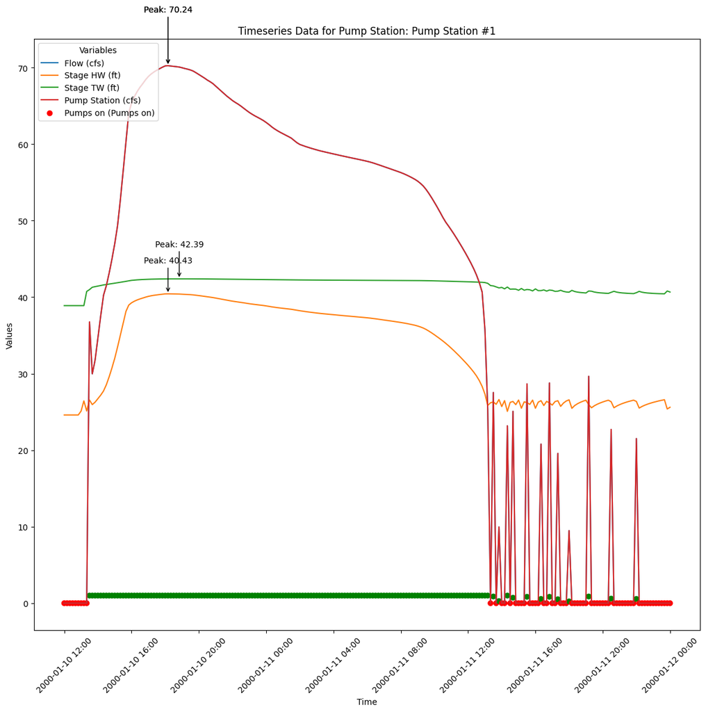

```python
# Extract the pump station timeseries data
pump_station_name = pump_stations_gdf.iloc[0]['Name']  # Get the first pump station name
pump_timeseries = HdfPump.get_pump_station_timeseries(plan_hdf_path, pump_station=pump_station_name)

# Print the pump station timeseries
print(f"\nPump Station Timeseries ({pump_station_name}):")
print(pump_timeseries)

# Create a new figure for plotting
fig, ax = plt.subplots(figsize=(12, 12))

# Plot each variable in the timeseries
for variable in pump_timeseries.coords['variable'].values:
    data = pump_timeseries.sel(variable=variable)

    # Decode units to strings
    unit = pump_timeseries.attrs["units"][list(pump_timeseries.coords["variable"].values).index(variable)][1].decode('utf-8')

    # Check if the variable is 'Pumps on' to plot it differently
    if variable == 'Pumps on':
        # Plot with color based on the on/off status
        colors = ['green' if val > 0 else 'red' for val in data.values.flatten()]
        ax.scatter(pump_timeseries['time'], data, label=f'{variable} ({unit})', color=colors)
    else:
        ax.plot(pump_timeseries['time'], data, label=f'{variable} ({unit})')

        # Label the peak values
        peak_time = pump_timeseries['time'][data.argmax()]
        peak_value = data.max()
        ax.annotate(f'Peak: {peak_value:.2f}', xy=(peak_time, peak_value),
                    xytext=(peak_time, peak_value + 0.1 * peak_value),
                    arrowprops=dict(facecolor='black', arrowstyle='->'),
                    fontsize=10, color='black', ha='center')

# Set the title and labels
ax.set_title(f'Timeseries Data for Pump Station: {pump_station_name}')
ax.set_xlabel('Time')
ax.set_ylabel('Values')

# Format the x-axis to show dates nicely
ax.xaxis.set_major_formatter(DateFormatter('%Y-%m-%d %H:%M'))
plt.xticks(rotation=45)

# Add a legend
ax.legend(title='Variables', loc='upper left')

# Adjust the layout
plt.tight_layout()

# Show the plot
plt.show()
```